# Spatial CODA

### 2.2.5 Model simulation 3

```r
RHO <- matrix(c(0.5, 0.2, 0.15, 0.3),
              nrow = L_simu, ncol = L_simu)
GAMMA <- matrix(c(0, 0.2, 0.4, 0),
                nrow = L_simu, ncol = L_simu)
```

We simulate the process:

```r
set.seed(1)
y_N_mod_3 <- simu_spatial_multi_y(X = x_simu, beta_true = beta_true,
                            method_simulate = "N",
                            Sigma = Sigma,
                            GAMMA = GAMMA,
                            RHO = RHO,
                            W = W_simu)
mapMAP@data[, c("y_N_mod_3_1", "y_N_mod_3_2")] <- y_N_mod_3
```

We plot the two component of $Y$ on the map:

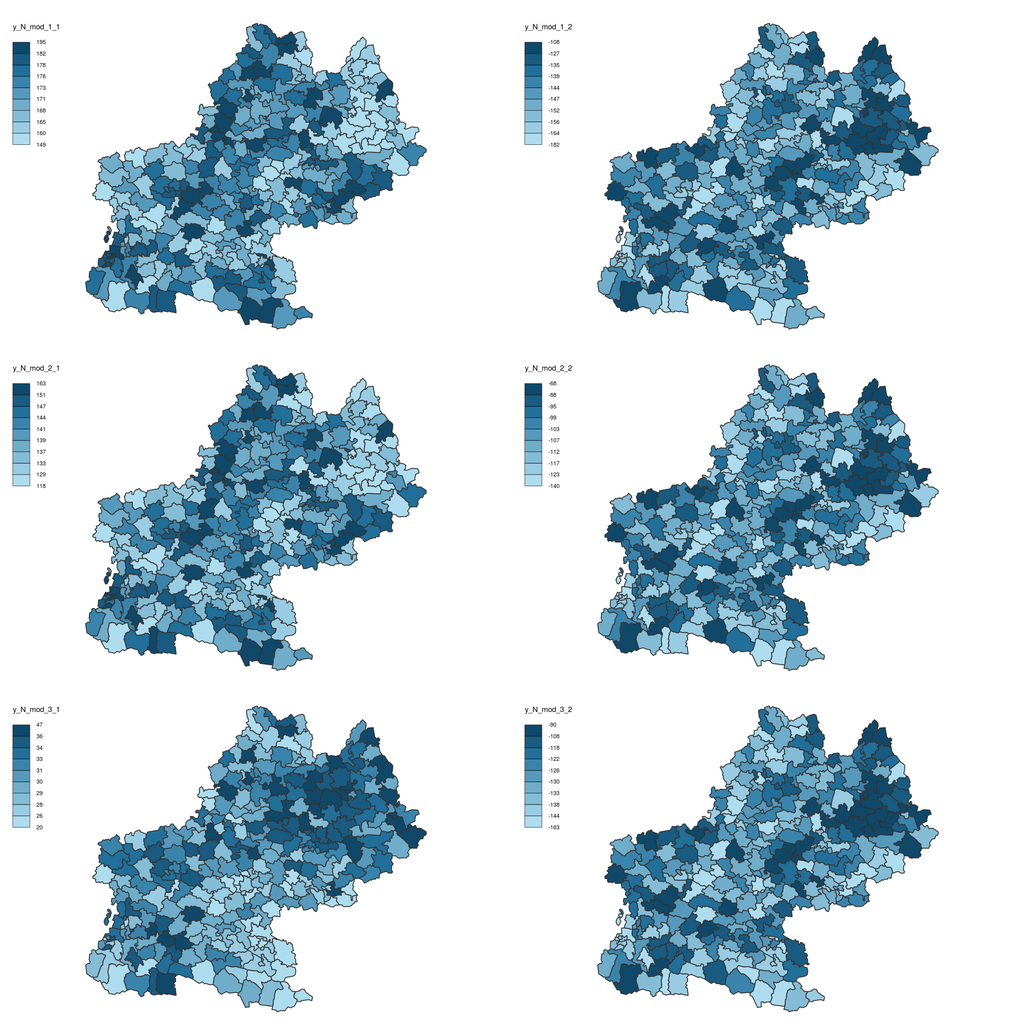

```r
library("cartography")
op <- par(mfrow = c(3, 2), oma = c(0, 0, 0, 0), mar = c(0, 0, 1, 0))
choroLayer(spdf = mapMAP, var = "y_N_mod_1_1", legend.pos = "topleft",
           method = "quantile")
choroLayer(spdf = mapMAP, var = "y_N_mod_1_2", legend.pos = "topleft",
           method = "quantile")
choroLayer(spdf = mapMAP, var = "y_N_mod_2_1", legend.pos = "topleft",
           method = "quantile")
choroLayer(spdf = mapMAP, var = "y_N_mod_2_2", legend.pos = "topleft",
           method = "quantile")
choroLayer(spdf = mapMAP, var = "y_N_mod_3_1", legend.pos = "topleft",
           method = "quantile")
choroLayer(spdf = mapMAP, var = "y_N_mod_3_2", legend.pos = "topleft",
           method = "quantile")
```

```r
par(op)
```

We also plot the joint distribution:

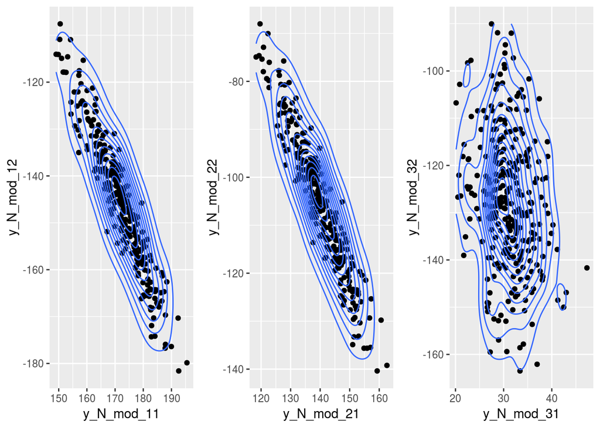

```r
y_N_df <- data.frame(y_N_mod_11 = y_N_mod_1[, 1],
                     y_N_mod_12 = y_N_mod_1[, 2],
                     y_N_mod_21 = y_N_mod_2[, 1],
                     y_N_mod_22 = y_N_mod_2[, 2],
                     y_N_mod_31 = y_N_mod_3[, 1],
                     y_N_mod_32 = y_N_mod_3[, 2],
                     x_simu)
plot1 <- ggplot(y_N_df, aes(x = y_N_mod_11, y = y_N_mod_12)) +
  geom_point() + geom_density_2d()
plot2 <- ggplot(y_N_df, aes(x = y_N_mod_21, y = y_N_mod_22)) +
  geom_point() + geom_density_2d()
plot3 <- ggplot(y_N_df, aes(x = y_N_mod_31, y = y_N_mod_32)) +
  geom_point() + geom_density_2d()
gridExtra::grid.arrange(plot1, plot2, plot3, nrow = 1, ncol = 3)
```

# 3 Estimation

## 3.1 Estimation of the parameters by a 2SLS method

The function *estimate_spatial_multi_N()* estimates the coefficients associated to the multivariate Gaussian SAR model. The algorithm is based on Kelejian and Prucha (1998).

Input arguments are :

- **Y**, a matrix of size $n \times L$
- **X**, a matrix of explanatory variables of size $n \times K$,
- **W**, a spatial weight matrix of size $n \times n$,
- **GAMMA_esti**, a boolean which indicates if we estimate or nor the parameter associated to $\Gamma$.

The function returns a list with :

- the estimate of the $\beta$ parameters
- the estimate of the $\Gamma$ matrix
- the estimate of the $R$ matrix
- the estimate of the $\Sigma$ matrix

To load the function:

```r
source("./R/estimate_spatial_multi_N.R")
source("./R/estimate_spatial_multi_gen_N.R")
```

### 3.1.1 Examples:

### 3.1.2 Model simulation 1

```r
(res_multi_N <- estimate_spatial_multi_gen_N(Y = y_N_mod_1, X = x_simu,
  W = W_simu,
  ind_beta = matrix(c(T, T, T, T, T, T, T, T, T, T, T, T), 4, 3),
  ind_RHO = matrix(c(T, F, F, T), 2, 2),
  ind_GAMMA = matrix(c(F, F, F, F), 2, 2)))
```

```
## $res_beta
##            [,1]      [,2]
## [1,] 10.6127684 14.583187
## [2,]  2.0483889 -2.979599
## [3,]  0.9841032 -1.991509
## [4,] -0.9333073  3.028197
##
## $GAMMA
##      [,1] [,2]
## [1,]    0    0
## [2,]    0    0
##
## $RHO
##           [,1]      [,2]
## [1,] 0.5237904 0.0000000
## [2,] 0.0000000 0.2680817
##
## $SIGMA
##             [,1]        [,2]
## [1,]  2.08942439 -0.06579664
## [2,] -0.06579664  2.78314431
```

Which is equivalent to :

```r
(s2sls_lm_1 <- stsls(y_N_mod_11 ~ x1 + x2 + x3, data = y_N_df, listw = W1.listw))
```

```
##
## Call:
## stsls(formula = y_N_mod_11 ~ x1 + x2 + x3, data = y_N_df, listw = W1.listw)
##
## Coefficients:
##         Rho (Intercept)          x1          x2          x3
##   0.5237904  10.6127684   2.0483889   0.9841032  -0.9333073
```

```r
(s2sls_lm_2 <- stsls(y_N_mod_12 ~ x1 + x2 + x3, data = y_N_df, listw = W1.listw))
```

```
##
## Call:
## stsls(formula = y_N_mod_12 ~ x1 + x2 + x3, data = y_N_df, listw = W1.listw)
##
## Coefficients:
##         Rho (Intercept)          x1          x2          x3
##   0.2680817  14.5831871  -2.9795985  -1.9915092   3.0281966
```

### 3.1.3 Model simulation 2

```r
(res_multi_N <- estimate_spatial_multi_gen_N(Y = y_N_mod_2, X = x_simu,
  W = W_simu,
  ind_beta = matrix(c(T, T, T, T, T, T, T, T, T, T, T, T), 4, 3),
  ind_RHO = matrix(c(T, T, T, T), 2, 2),
  ind_GAMMA = matrix(c(F, F, F, F), 2, 2)))
```

```
## $res_beta
##            [,1]      [,2]
## [1,]  9.2098179 19.562617
## [2,]  2.0474016 -2.971131
## [3,]  0.9855854 -1.992524
## [4,] -0.9337311  3.021586
##
## $GAMMA
##      [,1] [,2]
## [1,]    0    0
## [2,]    0    0
##
## $RHO
##           [,1]      [,2]
## [1,] 0.5513781 0.1666536
## [2,] 0.1404236 0.2245505
##
## $SIGMA
##             [,1]        [,2]
## [1,]  2.08466362 -0.05936801
## [2,] -0.05936801  2.78774972
```

### 3.1.4 Model simulation 3

```r
(res_multi_N <- estimate_spatial_multi_gen_N(Y = y_N_mod_3, X = x_simu,
  W = W_simu,
  ind_beta = matrix(c(T, T, T, T, T, T, T, T, T, T, T, T), 4, 3),
  ind_RHO = matrix(c(T, T, T, T), 2, 2),
  ind_GAMMA = matrix(c(F, T, T, F), 2, 2)))
```

```
## $res_beta
##            [,1]      [,2]
## [1,]  0.7177273  4.941842
## [2,]  3.4154366 -3.594369
## [3,]  1.9401087 -2.130969
## [4,] -2.4477609  2.839205
##
## $GAMMA
##           [,1]     [,2]
## [1,] 0.0000000 0.887644
## [2,] 0.8553006 0.000000
##
## $RHO
##            [,1]        [,2]
## [1,]  0.3868011 -0.02928875
## [2,] -0.2673855  0.10518122
##
## $SIGMA
##           [,1]      [,2]
## [1,]  2.517224 -2.457917
## [2,] -2.457917  2.560851
```

# 4 Application to the real data

We first load the data:

```r
source("R/preparation_base_ilr.R")
```

Then, we plot the data.

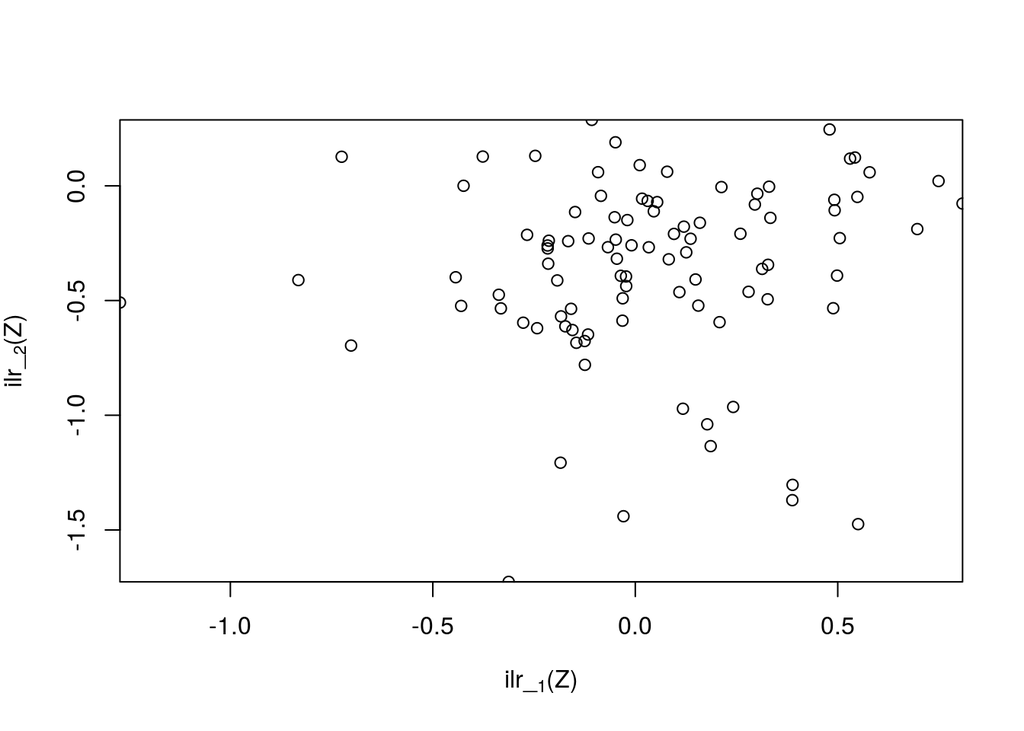

```r
Ye <- as(y_ilr, "matrix")
plot(Ye[,1], Ye[,2], xlab = expression(paste("ilr","_"[1],'(Z)')),
     ylab = expression(paste("ilr","_"[2],'(Z)')),
     xaxs = "i", yaxs = "i")
```

We prepare the explanatory variables:

```r
Xe <- as(cbind(1, x2_df[, c("age3_ilr1", "age3_ilr2",
                            "unemp_rate", "income_rate")]),
         "matrix")
```

## 4.1 Multivariate Gaussian model

We estimate first a multivariate gaussian model by using the *lm()* function.

```r
res_N <- lm(Ye ~ Xe - 1)
```

Then, we look the spatial distribution of the residuals. For this, we first compute a spatial weight matrix based on the 4-nearest neighbours.

```r
coords_fr <- coordinates(dep.2015.spdf)
W_listw <- nb2listw(knn2nb(knearneigh(coords_fr, 4)),
                    style = "W")
W_dep <- listw2mat(W_listw)
```

We test the spatial autocorrelation in the residuals component by component:

```r
moran.mc(residuals(res_N)[, 1], listw = W_listw, nsim = 1000)
```

```
##
##  Monte-Carlo simulation of Moran I
##
## data:  residuals(res_N)[, 1]
## weights: W_listw
## number of simulations + 1: 1001
##
## statistic = 0.25723, observed rank = 1001, p-value = 0.000999
## alternative hypothesis: greater
```

```r
moran.mc(residuals(res_N)[, 2], listw = W_listw, nsim = 1000)
```

```
##
##  Monte-Carlo simulation of Moran I
##
## data:  residuals(res_N)[, 2]
## weights: W_listw
## number of simulations + 1: 1001
##
## statistic = 0.24837, observed rank = 1001, p-value = 0.000999
## alternative hypothesis: greater
```

We plot the residuals:

```r
dep.2015.spdf@data[, c("res_y_1", "res_y_2")] <- residuals(res_N)
```

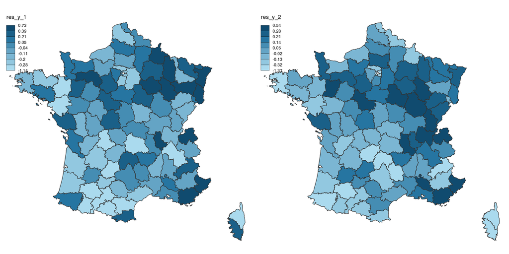

```r
library("cartography")
op <- par(mfrow = c(1, 2), oma = c(0, 0, 0, 0), mar = c(0, 0, 1, 0))
choroLayer(spdf = dep.2015.spdf, var = "res_y_1", legend.pos = "topleft",
           method = "quantile", legend.values.rnd = 2)
choroLayer(spdf = dep.2015.spdf, var = "res_y_2", legend.pos = "topleft",
           method = "quantile", legend.values.rnd = 2)
```

```r
par(op)
```

## 4.2 Multivariate Gaussian SAR model

```r
(res_sar_N <- estimate_spatial_multi_N(Ye, Xe, W_dep, GAMMA_esti = F))
```

```
## $res_beta
##            [,1]       [,2]
## [1,] -0.1969978 -3.1077680
## [2,]  0.2719789  0.8525314
## [3,]  0.2965863 -0.2870640
## [4,] -4.5082459 13.2323330
## [5,]  1.7306086  2.0687909
##
## $GAMMA
##      [,1] [,2]
## [1,]    0    0
## [2,]    0    0
##
## $RHO
##           [,1]      [,2]
## [1,] 0.8895999 0.5202213
## [2,] 0.5246872 0.6698683
##
## $SIGMA
##            [,1]       [,2]
## [1,] 0.08637361 0.01996587
## [2,] 0.01996587 0.08599642
```

# 5 References

- Goulard M., Laurent T. and Thomas-Agnan C. (2017). About predictions in spatial autoregressive models: optimal and almost optimal strategies, Spatial Economic Analysis, 12:2-3, 304-325, DOI: 10.1080/17421772.2017.1300679
- Nguyen T.H.A, Ruiz-Gazen, A., Thomas-Agnan C. and T. Laurent (2019). Multivariate Student versus Multivariate Gaussian Regression Models with Application to Finance. Journal of Risk and Financial Management, 12(1), 28.